# Aula 9 - Regressão Logística

29/09/2022

Para as bases de dados a seguir: (1) efetue uma regressão logística; (2) estime a probabilidade de sucesso para dois ou mais eventos; (3) plote a função sigmoide; (4) comente os resultados encontrados.

Bases de dados disponíveis em [RDatasets](https://vincentarelbundock.github.io/Rdatasets/datasets.html).

### 1 - *CollegeDistance* - College Distance Data.

```r
df <- read.csv("CollegeDistance.csv")
df$X = NULL
df$income = as.factor(df$income)
df$gender = as.factor(df$gender)
df$urban = as.factor(df$urban)
df$home = as.factor(df$home)
df$region = as.factor(df$region)

df$income_high = ifelse(df$income == 'high', 1, 0)

# A regressão:

fit = glm(income_high ~ score + fcollege + mcollege + home + education + urban + distance, data = df, family = binomial(link='logit'))

summary(fit)
```

```
##
## Call:
## glm(formula = income_high ~ score + fcollege + mcollege + home +
##     education + urban + distance, family = binomial(link = "logit"),
##     data = df)
##
## Deviance Residuals:
##     Min       1Q   Median       3Q      Max
## -1.7968  -0.7361  -0.5995   0.8411   2.5267
##
## Coefficients:
##              Estimate Std. Error z value Pr(>|z|)
## (Intercept) -4.103378   0.314940 -13.029  < 2e-16 ***
## score        0.009825   0.004676   2.101  0.03561 *
## fcollegeyes  1.314940   0.086602  15.184  < 2e-16 ***
## mcollegeyes  0.568524   0.101527   5.600 2.15e-08 ***
## homeyes      0.764805   0.107537   7.112 1.14e-12 ***
## education    0.129796   0.022055   5.885 3.98e-09 ***
## urbanyes    -0.366991   0.090350  -4.062 4.87e-05 ***
## distance    -0.066073   0.017989  -3.673  0.00024 ***
## ---
## Signif. codes:  0 '***' 0.001 '**' 0.01 '*' 0.05 '.' 0.1 ' ' 1
##
## (Dispersion parameter for binomial family taken to be 1)
##
##     Null deviance: 5690.4  on 4738  degrees of freedom
## Residual deviance: 4933.9  on 4731  degrees of freedom
## AIC: 4949.9
##
## Number of Fisher Scoring iterations: 4
```

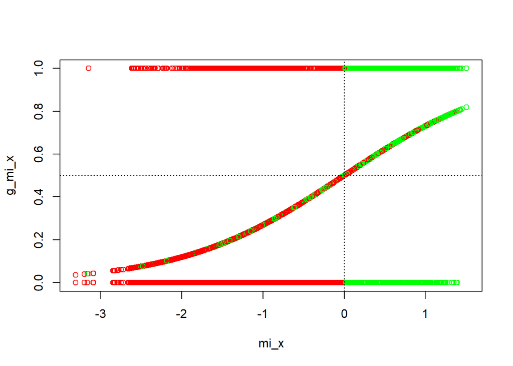

```r
# Plotar a sigmóide usando os dados usados para geração do modelo

# Primeiro faz o cálculo de beta0 + beta1*x1 + beta2*x2 ...
mi_x = predict(fit, df)
# Agora aplica a sigmóide nesses valores:
# Isso é equivalente a fazer o predict(fit, df, type='response')
g_mi_x = 1/(1 + exp(-1*mi_x))

# Plota mi(x) versus g(mi(x)) e pinta a sigmóide de verde e vermelho de acordo com o resultado esperado
plot(mi_x, g_mi_x, ylim=c(0,1), col=ifelse(df$income_high == 1, 'green', 'red'))

# Apresenta os pontos usados em treinamento em 0 (low) e 1 (high) e pinta de acordo com o valor predito
points(mi_x, df$income_high, col=ifelse(g_mi_x > 0.5, 'green', 'red'))

# Traça uma linha indicativa em x = 0 e y = 0.5
abline(h=0.5, col='black', lty=3)
abline(v=0, col='black', lty=3)
```

```r
predicao = as.factor(ifelse(g_mi_x > 0.5, 'high', 'low'))
confusionMatrix(predicao, df$income)
```

```
## Confusion Matrix and Statistics
##
##           Reference
## Prediction high  low
##       high  518  266
##       low   847 3108
##
##                Accuracy : 0.7651
##                  95% CI : (0.7528, 0.7771)
##     No Information Rate : 0.712
##     P-Value [Acc > NIR] : < 2.2e-16
##
##                   Kappa : 0.3443
##
##  Mcnemar's Test P-Value : < 2.2e-16
##
##             Sensitivity : 0.3795
##             Specificity : 0.9212
##          Pos Pred Value : 0.6607
##          Neg Pred Value : 0.7858
##              Prevalence : 0.2880
##          Detection Rate : 0.1093
##    Detection Prevalence : 0.1654
##       Balanced Accuracy : 0.6503
##
##        'Positive' Class : high
##
```

Comentários:

Fiz uma regressão logit de acordo com o seguinte modelo:

income_high ~ score + fcollege + mcollege + home + education + urban + distance

Há 4739 observações nessa base de treinamento, sendo 1365 indicando renda alta e indicando 3374 baixa renda.

A matriz de confusão do treinamento mostrou que:

- dos 1365 dados indicando renda alta, o modelo identificou corretamente apenas 518 deles. Os outros 847 foram identificados como baixa renda
- dos 3374 dados indicando baixa renda, o modelo identificou corretamente 3108 deles. Os outros 266 foram identificados como alta renda.

O que podemos concluir aqui é que há bem mais dados indicando baixa renda, e assim o modelo acabou reduzindo o erro na estimação dessa classe em relação à outra. De forma geral, 3626 observações da base foram identificadas corretamente (3626/4739 = 0,7651), indicando acurácia de 76,51%.

Isso fica mais claro vendo o desenho da sigmóide no gráfico acima. Na curva da sigmóide os dados foram coloridos indicando se a observação de income relativa a u(x) é alta (verde) ou baixa (vermelha). Além disso, os mesmos dados foram mostrados em 1 (alta) e 0 (baixa) e, nessa escala, coloridos de acordo com a forma como foram classificados (ou seja, os dados classificados errados são aqueles que estão em vermelho em y = 1 ou em verde em y = 0).

### 2 - *pancreatic*

```r
df <- read.csv("pancreatic.csv")
df$X = NULL
df$stage = as.factor(df$stage)
df$onstudy = as.Date(df$onstudy, "%m/%d/%Y")
df$progression = as.Date(df$progression, "%m/%d/%Y")
df$death = as.Date(df$death, "%m/%d/%Y")
df$dias_ate_morte = as.integer(df$death - df$onstudy)
df$local = ifelse(df$stage == 'LA', 1, 0)

fit = glm(local ~ dias_ate_morte, data = df, family = binomial(link='logit'))

summary(fit)
```

```
##
## Call:
## glm(formula = local ~ dias_ate_morte, family = binomial(link = "logit"),
##     data = df)
##
## Deviance Residuals:
##     Min       1Q   Median       3Q      Max
## -0.9861  -0.6537  -0.6093  -0.5749   1.9134
##
## Coefficients:
##                 Estimate Std. Error z value Pr(>|z|)
## (Intercept)    -1.782566   0.660134  -2.700  0.00693 **
## dias_ate_morte  0.001348   0.001844   0.731  0.46461
## ---
## Signif. codes:  0 '***' 0.001 '**' 0.01 '*' 0.05 '.' 0.1 ' ' 1
##
## (Dispersion parameter for binomial family taken to be 1)
##
##     Null deviance: 40.472  on 40  degrees of freedom
## Residual deviance: 39.959  on 39  degrees of freedom
## AIC: 43.959
##
## Number of Fisher Scoring iterations: 4
```

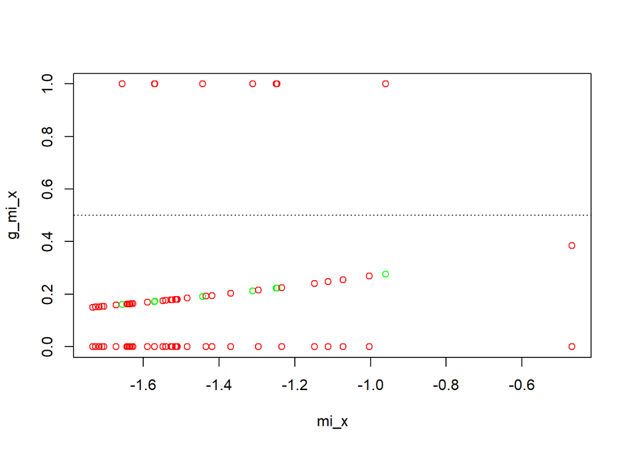

```r
# Plotar a sigmóide usando os dados usados para geração do modelo

# Primeiro faz o cálculo de beta0 + beta1*x1 + beta2*x2 ...
mi_x = predict(fit, df)
# Agora aplica a sigmóide nesses valores:
# Isso é equivalente a fazer o predict(fit, df, type='response')
g_mi_x = 1/(1 + exp(-1*mi_x))

# Plota mi(x) versus g(mi(x)) e pinta a sigmóide de verde e vermelho de acordo com o resultado esperado
plot(mi_x, g_mi_x, ylim=c(0,1), col=ifelse(df$local == 1, 'green', 'red'))

# Apresenta os pontos usados em treinamento em 0 (low) e 1 (high) e pinta de acordo com o valor predito
points(mi_x, df$local, col=ifelse(g_mi_x > 0.5, 'green', 'red'))

# Traça uma linha indicativa em x = 0 e y = 0.5
abline(h=0.5, col='black', lty=3)
abline(v=0, col='black', lty=3)
```

```r
predicao = as.factor(ifelse(g_mi_x > 0.5, 'LA', 'M'))
confusionMatrix(predicao, df$stage)
```

```
## Confusion Matrix and Statistics
##
##           Reference
## Prediction LA  M
##         LA  0  0
##         M   8 33
##
##                Accuracy : 0.8049
##                  95% CI : (0.6513, 0.9118)
##     No Information Rate : 0.8049
##     P-Value [Acc > NIR] : 0.59310
##
##                   Kappa : 0
##
##  Mcnemar's Test P-Value : 0.01333
##
##             Sensitivity : 0.0000
##             Specificity : 1.0000
##          Pos Pred Value :    NaN
##          Neg Pred Value : 0.8049
##              Prevalence : 0.1951
##          Detection Rate : 0.0000
##    Detection Prevalence : 0.0000
##       Balanced Accuracy : 0.5000
##
##        'Positive' Class : LA
##
```

De acordo com o dicionário, essa base de dados contém 41 observações dessas variáveis:

- stage: a factor with levels LA (locally advanced) or M (metastatic)
- onstudy: date of enrollment into the clinical trial, in month/day/year format
- progression: date of progression, in month/day/year format
- death: date of death, in month/day/year format

Não entendi direito o que significa as variáveis, especialmente a variável “progression”. Então para fazer um teste, eu criei uma nova coluna com a diferença entre as variáveis death e onstudy. Chamei essa variável de df$dias_ate_morte e ela contém quantos dias levou até a morte do paciente contados a partir de quando a pessoa entrou no estudo.

Considerando que queremos aplicar a logit, vamos ver se há alguma forma de, usando essa única informação de dias_ate_morte, prever se o estágio era LA (local) ou M (metastático). Essa informação realmente não serve pra nada e é apenas uma curiosidade de exercício aqui.

O resultado que ocorreu é que o modelo treinado simplesmente preveu todo mundo como metastático. É um modelo que não tem utilidade.

### 3 - * PhDPublications* - Doctoral Publications.

```r
df <- read.csv("PhDPublications.csv")
df$X = NULL
df$gender = as.factor(df$gender)
df$married = as.factor(df$married)

df$gender_male = ifelse(df$gender == 'male', 1, 0)

fit = glm(gender_male ~ articles + married + kids + prestige + mentor, data = df, family = binomial(link='logit'))
summary(fit)
```

```
##
## Call:
## glm(formula = gender_male ~ articles + married + kids + prestige +
##     mentor, family = binomial(link = "logit"), data = df)
##
## Deviance Residuals:
##     Min       1Q   Median       3Q      Max
## -2.1904  -1.0619   0.5659   1.0674   1.5774
##
## Coefficients:
##              Estimate Std. Error z value Pr(>|z|)
## (Intercept) -1.013189   0.266158  -3.807 0.000141 ***
## articles     0.120657   0.041928   2.878 0.004006 **
## marriedyes   0.582843   0.164838   3.536 0.000406 ***
## kids         0.749311   0.118889   6.303 2.93e-10 ***
## prestige     0.051979   0.075035   0.693 0.488476
## mentor       0.010913   0.008616   1.267 0.205316
## ---
## Signif. codes:  0 '***' 0.001 '**' 0.01 '*' 0.05 '.' 0.1 ' ' 1
##
## (Dispersion parameter for binomial family taken to be 1)
##
##     Null deviance: 1262.6  on 914  degrees of freedom
## Residual deviance: 1145.8  on 909  degrees of freedom
## AIC: 1157.8
##
## Number of Fisher Scoring iterations: 4
```

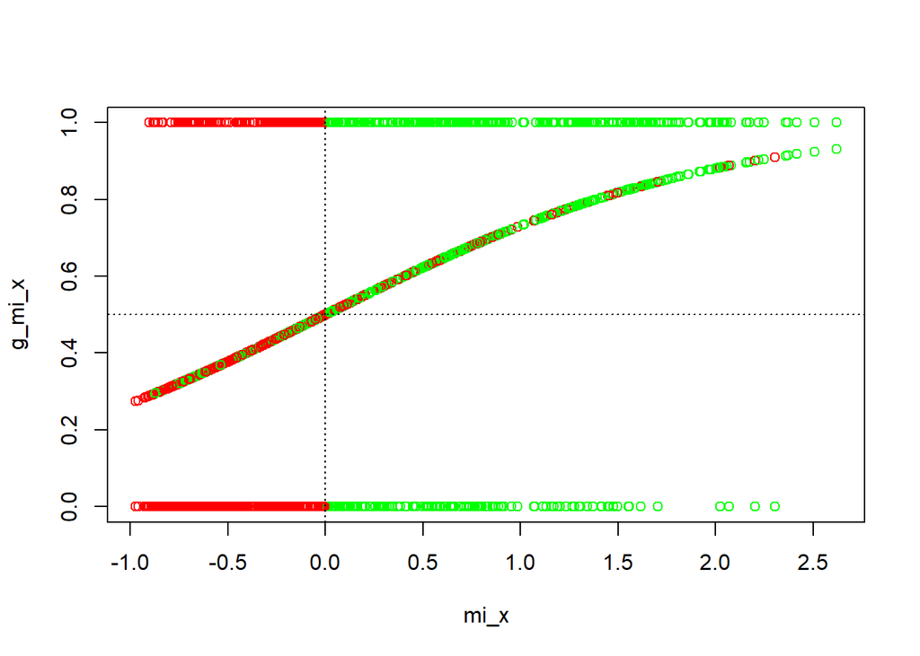

```r
# Primeiro faz o cálculo de beta0 + beta1*x1 + beta2*x2 ...
mi_x = predict(fit, df)
# Agora aplica a sigmóide nesses valores:
# Isso é equivalente a fazer o predict(fit, df, type='response')
g_mi_x = 1/(1 + exp(-1*mi_x))

# Plota mi(x) versus g(mi(x)) e pinta a sigmóide de verde e vermelho de acordo com o resultado esperado
plot(mi_x, g_mi_x, ylim=c(0,1), col=ifelse(df$gender_male == 1, 'green', 'red'))

# Apresenta os pontos usados em treinamento em 0 (low) e 1 (high) e pinta de acordo com o valor predito
points(mi_x, df$gender_male, col=ifelse(g_mi_x > 0.5, 'green', 'red'))

# Traça uma linha indicativa em x = 0 e y = 0.5
abline(h=0.5, col='black', lty=3)
abline(v=0, col='black', lty=3)
```

```r
predicao = as.factor(ifelse(g_mi_x > 0.5, 'male', 'female'))
confusionMatrix(predicao, df$gender)
```

```
## Confusion Matrix and Statistics
##
##           Reference
## Prediction female male
##     female    273  179
##     male      148  315
##
##                Accuracy : 0.6426
##                  95% CI : (0.6106, 0.6737)
##     No Information Rate : 0.5399
##     P-Value [Acc > NIR] : 1.955e-10
##
##                   Kappa : 0.2846
##
##  Mcnemar's Test P-Value : 0.09712
##
##             Sensitivity : 0.6485
##             Specificity : 0.6377
##          Pos Pred Value : 0.6040
##          Neg Pred Value : 0.6803
##              Prevalence : 0.4601
##          Detection Rate : 0.2984
##    Detection Prevalence : 0.4940
##       Balanced Accuracy : 0.6431
##
##        'Positive' Class : female
##
```

Nesse exemplo foi feito um modelo tentando identificar o gênero (masculino ou feminino) de acordo com todas as outras variáveis (articles, married, kids, prestige e mentor).

O gráfico da sigmóide tem a mesma interpretação do exemplo 1. Ocorre que o modelo aqui tem precisão de apenas 64%. Apesar de ser um número baixo, é cerca de 10 pontos percentuais a mais do que a quantidade de gênero male na base (54%).

### 4 - Escolha uma base de dados e efetue os comandos do exercício.

```r
df <- read.csv("tips.csv")
df$X = NULL
df$day = as.factor(df$day)
df$tip_percentual = df$tip/df$bill

df$sexta = ifelse(df$day == 'Friday', 1, 0)


fit = glm(sexta ~ tip_percentual, data = df, family = binomial(link='logit'))
summary(fit)
```

```
##
## Call:
## glm(formula = sexta ~ tip_percentual, family = binomial(link = "logit"),
##     data = df)
##
## Deviance Residuals:
##     Min       1Q   Median       3Q      Max
## -1.4957  -1.2831   0.9714   1.0749   1.3260
##
## Coefficients:
##                Estimate Std. Error z value Pr(>|z|)
## (Intercept)      0.8692     0.5510   1.577    0.115
## tip_percentual  -3.4625     2.7702  -1.250    0.211
##
## (Dispersion parameter for binomial family taken to be 1)
##
##     Null deviance: 130.42  on 94  degrees of freedom
## Residual deviance: 128.81  on 93  degrees of freedom
## AIC: 132.81
##
## Number of Fisher Scoring iterations: 4
```

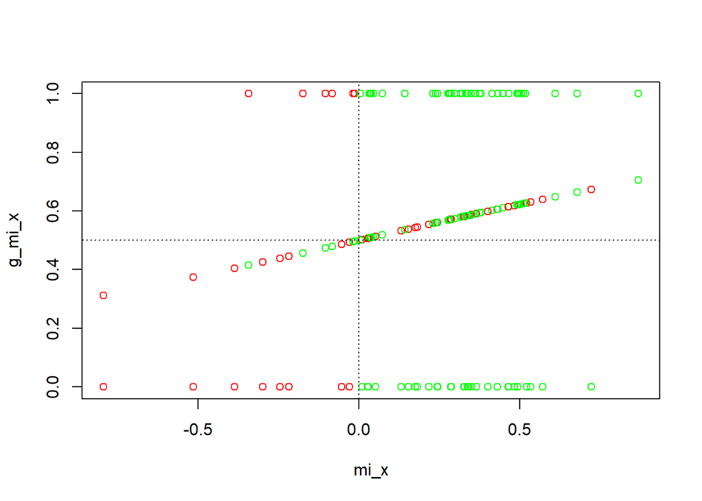

```r
# Primeiro faz o cálculo de beta0 + beta1*x1 + beta2*x2 ...
mi_x = predict(fit, df)
# Agora aplica a sigmóide nesses valores:
# Isso é equivalente a fazer o predict(fit, df, type='response')
g_mi_x = 1/(1 + exp(-1*mi_x))

# Plota mi(x) versus g(mi(x)) e pinta a sigmóide de verde e vermelho de acordo com o resultado esperado
plot(mi_x, g_mi_x, ylim=c(0,1), col=ifelse(df$sexta == 1, 'green', 'red'))

# Apresenta os pontos usados em treinamento em 0 (low) e 1 (high) e pinta de acordo com o valor predito
points(mi_x, df$sexta, col=ifelse(g_mi_x > 0.5, 'green', 'red'))

# Traça uma linha indicativa em x = 0 e y = 0.5
abline(h=0.5, col='black', lty=3)
abline(v=0, col='black', lty=3)
```

```r
predicao = as.factor(ifelse(g_mi_x > 0.5, 'Friday', 'Tuesday'))
confusionMatrix(predicao, df$day)
```

```
## Confusion Matrix and Statistics
##
##           Reference
## Prediction Friday Tuesday
##    Friday      47      34
##    Tuesday      6       8
##
##                Accuracy : 0.5789
##                  95% CI : (0.4733, 0.6796)
##     No Information Rate : 0.5579
##     P-Value [Acc > NIR] : 0.3798
##
##                   Kappa : 0.083
##
##  Mcnemar's Test P-Value : 1.963e-05
##
##             Sensitivity : 0.8868
##             Specificity : 0.1905
##          Pos Pred Value : 0.5802
##          Neg Pred Value : 0.5714
##              Prevalence : 0.5579
##          Detection Rate : 0.4947
##    Detection Prevalence : 0.8526
##       Balanced Accuracy : 0.5386
##
##        'Positive' Class : Friday
##
```

Escolhi a base de dados tips que relaciona o valor de uma gorjeta/conta com o dia da semana (terça ou sexta) relacionada a conta. A ideia é apenas checar se há alguma diferença significativa no valor da gorjeta dada nas terças ou nas sextas.

O modelo escolhido foi sexta ~ tip_percentual. O resultado do modelo foi uma acurácia de 57,9%. Esse valor é ligeiramente superior a 55,8% (a quantiade de sexta feira na base). Ou seja, nessa base de dados o percentual de gorjeta sozinho não é um bom preditor para dizer se a conta foi feita na terça ou na sexta.